# Bank Marketing Exploratory Data Analysis and Visualization

[figure not shown]

## 1 Introduction

Data Bank Marketing adalah data yang terkait dengan pemasaran langsung yang didasarkan pada panggilan telepon.Adapun data tersebut memiliki tujuan untuk memprediksi apakah nasabah akan berlangganan deposito berjangka atau tidak.

## 2 Data Preparation

Data Preparation adalah proses menyiapkan data mentah agar dapat diproses dan dianalisis lebih lanjut.

### 2.1 Importing Libraries

Langkah pertama dalam data preparation yaitu memanggil seluruh package yang akan digunakan.

```r
# Data Processing
library(lubridate)
# Data Wrangling
library(tidyr)
library(stringr)
library(tidyverse)
# Visualization
library(ggplot2)
library(grid)
library(shadowtext)
library(gridExtra)
library(ggstatsplot)
library(plotly)
```

### 2.2 Importing Datasets

Inspeksi data menggunakan `head` setelah import dataset diperlukan untuk identifikasi awal mengenai kolom dari dataset.

```r
bmdat <- read.csv("bank.csv", sep = ';', header = TRUE)
head(bmdat)
```

```
#>   age         job marital education default balance housing loan  contact day
#> 1  30  unemployed married   primary      no    1787      no   no cellular  19
#> 2  33    services married secondary      no    4789     yes  yes cellular  11
#> 3  35  management  single  tertiary      no    1350     yes   no cellular  16
#> 4  30  management married  tertiary      no    1476     yes  yes  unknown   3
#> 5  59 blue-collar married secondary      no       0     yes   no  unknown   5
#> 6  35  management  single  tertiary      no     747      no   no cellular  23
#>   month duration campaign pdays previous poutcome  y
#> 1   oct       79        1    -1        0  unknown no
#> 2   may      220        1   339        4  failure no
#> 3   apr      185        1   330        1  failure no
#> 4   jun      199        4    -1        0  unknown no
#> 5   may      226        1    -1        0  unknown no
#> 6   feb      141        2   176        3  failure no
```

## 3 Data Processing

Data preprocessing adalah proses mengubah data mentah menjadi format yang lebih mudah dipahami.

### 3.1 Duplicates

Langkah pertama adalah melakukan pengecekan data duplikat.

```r
sum(duplicated(bmdat))
```

```
#> [1] 0
```

Berdasarkan hasil pengecekan, tidak ditemukan data yang terduplikat.

### 3.2 Missing Values

Langkah selanjutnya adalah melakukan pengecekan missing values.

```r
str(bmdat)
```

```
#> 'data.frame':    4521 obs. of  17 variables:
#>  $ age      : int  30 33 35 30 59 35 36 39 41 43 ...
#>  $ job      : chr  "unemployed" "services" "management" "management" ...
#>  $ marital  : chr  "married" "married" "single" "married" ...
#>  $ education: chr  "primary" "secondary" "tertiary" "tertiary" ...
#>  $ default  : chr  "no" "no" "no" "no" ...
#>  $ balance  : int  1787 4789 1350 1476 0 747 307 147 221 -88 ...
#>  $ housing  : chr  "no" "yes" "yes" "yes" ...
#>  $ loan     : chr  "no" "yes" "no" "yes" ...
#>  $ contact  : chr  "cellular" "cellular" "cellular" "unknown" ...
#>  $ day      : int  19 11 16 3 5 23 14 6 14 17 ...
#>  $ month    : chr  "oct" "may" "apr" "jun" ...
#>  $ duration : int  79 220 185 199 226 141 341 151 57 313 ...
#>  $ campaign : int  1 1 1 4 1 2 1 2 2 1 ...
#>  $ pdays    : int  -1 339 330 -1 -1 176 330 -1 -1 147 ...
#>  $ previous : int  0 4 1 0 0 3 2 0 0 2 ...
#>  $ poutcome : chr  "unknown" "failure" "failure" "unknown" ...
#>  $ y        : chr  "no" "no" "no" "no" ...
```

```r
colSums(is.na(x=bmdat))
```

```
#>       age       job   marital education   default   balance   housing      loan
#>         0         0         0         0         0         0         0         0
#>   contact       day     month  duration  campaign     pdays  previous  poutcome
#>         0         0         0         0         0         0         0         0
#>         y
#>         0
```

Berdasarkan hasil pengecekan, tidak ditemukan data yang hilang atau kosong.

### 3.3 Data Types

Selanjutnya dilakukan pengecekan tipe data.

```r
str(bmdat)
```

```
#> 'data.frame':    4521 obs. of  17 variables:
#>  $ age      : int  30 33 35 30 59 35 36 39 41 43 ...
#>  $ job      : chr  "unemployed" "services" "management" "management" ...
#>  $ marital  : chr  "married" "married" "single" "married" ...
#>  $ education: chr  "primary" "secondary" "tertiary" "tertiary" ...
#>  $ default  : chr  "no" "no" "no" "no" ...
#>  $ balance  : int  1787 4789 1350 1476 0 747 307 147 221 -88 ...
#>  $ housing  : chr  "no" "yes" "yes" "yes" ...
#>  $ loan     : chr  "no" "yes" "no" "yes" ...
#>  $ contact  : chr  "cellular" "cellular" "cellular" "unknown" ...
#>  $ day      : int  19 11 16 3 5 23 14 6 14 17 ...
#>  $ month    : chr  "oct" "may" "apr" "jun" ...
#>  $ duration : int  79 220 185 199 226 141 341 151 57 313 ...
#>  $ campaign : int  1 1 1 4 1 2 1 2 2 1 ...
#>  $ pdays    : int  -1 339 330 -1 -1 176 330 -1 -1 147 ...
#>  $ previous : int  0 4 1 0 0 3 2 0 0 2 ...
#>  $ poutcome : chr  "unknown" "failure" "failure" "unknown" ...
#>  $ y        : chr  "no" "no" "no" "no" ...
```

Variabel yang memiliki tipe data tidak sesuai dan perlu disesuaikan: 1. Job, Marital, Education, Default, Housing, Loan, Contact, Poutcom, Y : Kategorik 2.Month, Day : Date Berikut akan dilakukan perubahan tipe data untuk data kategorik.

```r
cols <- c("job","marital","education","default", "housing", "loan","contact","poutcome", "y")
bmdat[cols] = lapply(X=bmdat[cols], FUN = as.factor)
head(bmdat[cols])
```

```
#>           job marital education default housing loan  contact poutcome  y
#> 1  unemployed married   primary      no      no   no cellular  unknown no
#> 2    services married secondary      no     yes  yes cellular  failure no
#> 3  management  single  tertiary      no     yes   no cellular  failure no
#> 4  management married  tertiary      no     yes  yes  unknown  unknown no
#> 5 blue-collar married secondary      no     yes   no  unknown  unknown no
#> 6  management  single  tertiary      no      no   no cellular  failure no
```

Selanjutnya dilakukan perubahan tipe data Date.

```r
unique(bmdat$month)
```

```
#>  [1] "oct" "may" "apr" "jun" "feb" "aug" "jan" "jul" "nov" "sep" "mar" "dec"
```

```r
unique(bmdat$day)
```

```
#>  [1] 19 11 16  3  5 23 14  6 17 20 13 30 29 27  7 18 12 21 26 22  2  4 15  8 28
#> [26]  9  1 10 31 25 24
```

```r
bmdat['day_month'] = paste(bmdat$day, bmdat$month, '2012', sep=" ")
head(bmdat$day_month)
```

```
#> [1] "19 oct 2012" "11 may 2012" "16 apr 2012" "3 jun 2012"  "5 may 2012"
#> [6] "23 feb 2012"
```

```r
bmdat$day_month <-dmy(bmdat$day_month)
head(bmdat$day_month)
```

```
#> [1] "2012-10-19" "2012-05-11" "2012-04-16" "2012-06-03" "2012-05-05"
#> [6] "2012-02-23"
```

```r
bmdat['year_month'] <-substr(bmdat$day_month,1,7)
head(bmdat$year_month)
```

```
#> [1] "2012-10" "2012-05" "2012-04" "2012-06" "2012-05" "2012-02"
```

```r
bmdat$year_month <- as.Date(paste0(as.character(bmdat$year_month), "-01"), format = "%Y-%m-%d")
head(bmdat$year_month)
```

```
#> [1] "2012-10-01" "2012-05-01" "2012-04-01" "2012-06-01" "2012-05-01"
#> [6] "2012-02-01"
```

```r
str(bmdat)
```

```
#> 'data.frame':    4521 obs. of  19 variables:
#>  $ age       : int  30 33 35 30 59 35 36 39 41 43 ...
#>  $ job       : Factor w/ 12 levels "admin.","blue-collar",..: 11 8 5 5 2 5 7 10 3 8 ...
#>  $ marital   : Factor w/ 3 levels "divorced","married",..: 2 2 3 2 2 3 2 2 2 2 ...
#>  $ education : Factor w/ 4 levels "primary","secondary",..: 1 2 3 3 2 3 3 2 3 1 ...
#>  $ default   : Factor w/ 2 levels "no","yes": 1 1 1 1 1 1 1 1 1 1 ...
#>  $ balance   : int  1787 4789 1350 1476 0 747 307 147 221 -88 ...
#>  $ housing   : Factor w/ 2 levels "no","yes": 1 2 2 2 2 1 2 2 2 2 ...
#>  $ loan      : Factor w/ 2 levels "no","yes": 1 2 1 2 1 1 1 1 1 2 ...
#>  $ contact   : Factor w/ 3 levels "cellular","telephone",..: 1 1 1 3 3 1 1 1 3 1 ...
#>  $ day       : int  19 11 16 3 5 23 14 6 14 17 ...
#>  $ month     : chr  "oct" "may" "apr" "jun" ...
#>  $ duration  : int  79 220 185 199 226 141 341 151 57 313 ...
#>  $ campaign  : int  1 1 1 4 1 2 1 2 2 1 ...
#>  $ pdays     : int  -1 339 330 -1 -1 176 330 -1 -1 147 ...
#>  $ previous  : int  0 4 1 0 0 3 2 0 0 2 ...
#>  $ poutcome  : Factor w/ 4 levels "failure","other",..: 4 1 1 4 4 1 2 4 4 1 ...
#>  $ y         : Factor w/ 2 levels "no","yes": 1 1 1 1 1 1 1 1 1 1 ...
#>  $ day_month : Date, format: "2012-10-19" "2012-05-11" ...
#>  $ year_month: Date, format: "2012-10-01" "2012-05-01" ...
```

## 4 Exploratory Data Analysis

```r
summary(bmdat)
```

```
#>       age                 job          marital         education    default
#>  Min.   :19.00   management :969   divorced: 528   primary  : 678   no :4445
#>  1st Qu.:33.00   blue-collar:946   married :2797   secondary:2306   yes:  76
#>  Median :39.00   technician :768   single  :1196   tertiary :1350
#>  Mean   :41.17   admin.     :478                   unknown  : 187
#>  3rd Qu.:49.00   services   :417
#>  Max.   :87.00   retired    :230
#>                  (Other)    :713
#>     balance      housing     loan           contact          day
#>  Min.   :-3313   no :1962   no :3830   cellular :2896   Min.   : 1.00
#>  1st Qu.:   69   yes:2559   yes: 691   telephone: 301   1st Qu.: 9.00
#>  Median :  444                         unknown  :1324   Median :16.00
#>  Mean   : 1423                                          Mean   :15.92
#>  3rd Qu.: 1480                                          3rd Qu.:21.00
#>  Max.   :71188                                          Max.   :31.00
#>
#>     month              duration       campaign          pdays
#>  Length:4521        Min.   :   4   Min.   : 1.000   Min.   : -1.00
#>  Class :character   1st Qu.: 104   1st Qu.: 1.000   1st Qu.: -1.00
#>  Mode  :character   Median : 185   Median : 2.000   Median : -1.00
#>                     Mean   : 264   Mean   : 2.794   Mean   : 39.77
#>                     3rd Qu.: 329   3rd Qu.: 3.000   3rd Qu.: -1.00
#>                     Max.   :3025   Max.   :50.000   Max.   :871.00
#>
#>     previous          poutcome      y          day_month
#>  Min.   : 0.0000   failure: 490   no :4000   Min.   :2012-01-07
#>  1st Qu.: 0.0000   other  : 197   yes: 521   1st Qu.:2012-05-11
#>  Median : 0.0000   success: 129              Median :2012-06-05
#>  Mean   : 0.5426   unknown:3705              Mean   :2012-06-20
#>  3rd Qu.: 0.0000                             3rd Qu.:2012-08-05
#>  Max.   :25.0000                             Max.   :2012-12-31
#>
#>    year_month
#>  Min.   :2012-01-01
#>  1st Qu.:2012-05-01
#>  Median :2012-06-01
#>  Mean   :2012-06-05
#>  3rd Qu.:2012-08-01
#>  Max.   :2012-12-01
#>
```

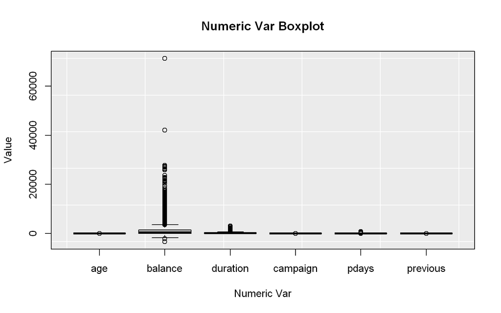

```r
cols_2 <- c("age","balance","duration","campaign","pdays","previous")
boxdat <- bmdat[cols_2]
# Light gray background
plot.new()
rect(par("usr")[1], par("usr")[3], par("usr")[2], par("usr")[4],
     col = "#ebebeb")

# Add white grid
grid(nx = NULL, ny = NULL, col = "white", lty = 1,lwd = par("lwd"), equilogs = TRUE)

# Boxplot
par(new=TRUE)
boxplot(boxdat, col = "grey", xlab = "Numeric Var", ylab = "Value", main = "Numeric Var Boxplot")
```

Boxplot digunakan untuk melihat adanya pencilan dari variabel.

```r
# Add Col
bmdat['freq'] = cbind(matrix(1,4521,1))
head(bmdat$freq)
```

```
#>      [,1]
#> [1,]    1
#> [2,]    1
#> [3,]    1
#> [4,]    1
#> [5,]    1
#> [6,]    1
```

## 5 Exploratory Visualization

Explanatory visualization adalah bagan atau grafik yang digunakan untuk menjelaskan hasil analisis data kepada orang lain.

### 1 Marketing Campaigns by Date

Visualisasi pertama ini bertujuan untuk melihat bagaimana pola jumlah kampanye setiap harinya.

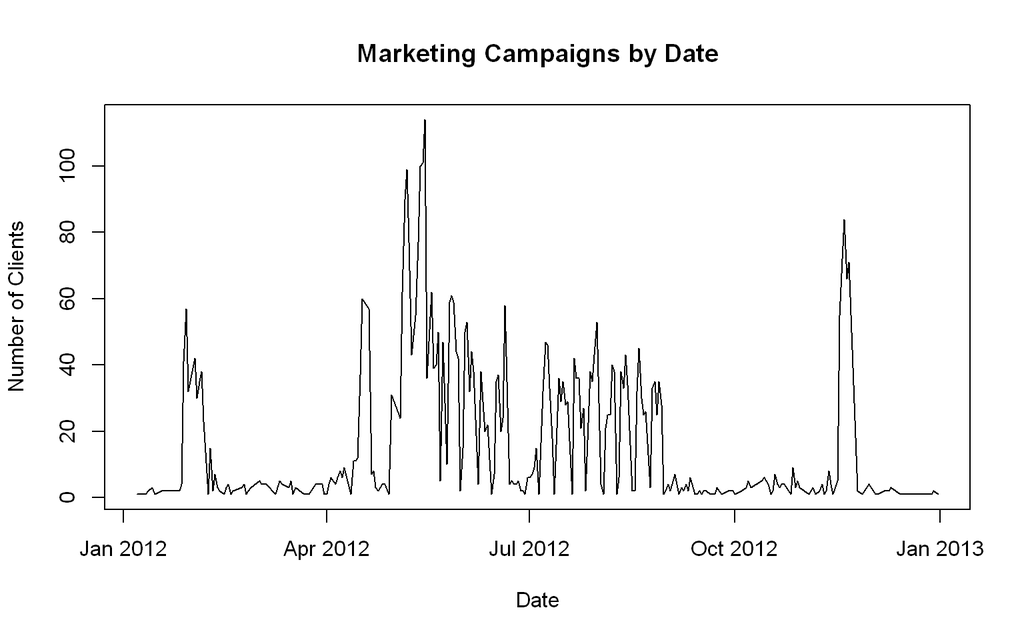

```r
# Persebaran by Day
freq_day = as.data.frame(table(bmdat$day_month))
freq_day$Var1 <- ymd(freq_day$Var1)
plot(x = freq_day$Var1, y = freq_day$Freq, type = 'l', main = "Marketing Campaigns by Date", xlab = 'Date', ylab = 'Number of Clients')
```

Plot tersebut memiliki pola yang fluktuatif dan memiliki varians yang tinggi.

### 2 Marketing Campaigns by Month

Visualisasi kedua ini bertujuan untuk melihat bagaimana pola jumlah kampanye setiap bulan

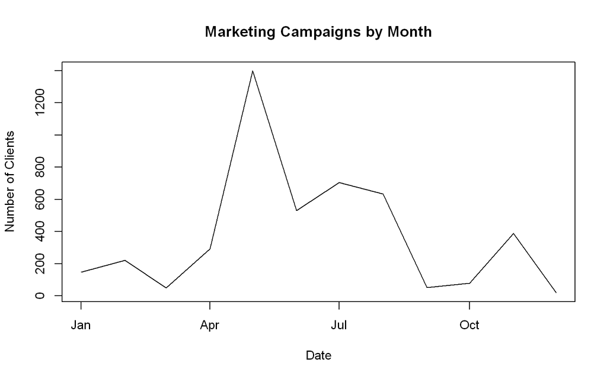

```r
# Persebaran by Month
freq_month = as.data.frame(table(bmdat$year_month))
freq_month$Var1 <- ymd(freq_month$Var1)
plot(x = freq_month$Var1, y = freq_month$Freq, type = 'l', main = "Marketing Campaigns by Month", xlab = 'Date', ylab = 'Number of Clients')
```

Pada plot bulanan, dapat dilihat terdapat kenaikan signifikan pada bulan Mei. Hal ini dapat dijadikan informasi pertama yang bermanfaat untuk analisa selanjutnya.

### 3 Term Deposit Proportion

Visualisasi ketiga merupakan visualisasi untuk melihat seberapa besar proporsi pelanggan yang telah berlangganan deposito berjangka. Setting warna:

```r
# The colors
BLUE <- "#076fa2"
RED <- "#E3120B"
BLACK <- "#202020"
GREY <- "grey50"
```

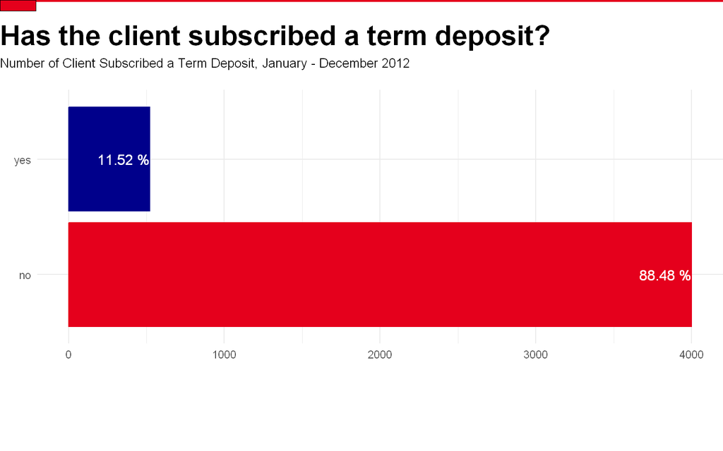

```r
plot1 <- ggplot(bmdat, aes(x = y, fill = y)) +
geom_bar(position = "dodge", fill = c("#e5001c", "darkblue"), color = c("#e5001c", "darkblue")) +
      coord_flip() +
      geom_text(aes(label = paste(round(..count../nrow(bmdat)*100,2), "%")),
                stat = "count",
                position = 'dodge',
                hjust = 1,
                size = 4,
                inherit.aes = TRUE,
                col = 'white') +
      theme_minimal() +
      theme(legend.position = "none",
            axis.title=element_blank(),
            panel.border=element_blank())

plot1 <- plot1 +   labs(title = NULL, subtitle = NULL) + theme(
  plot.margin = margin(0.2, 0, 0.2, 0.02, "npc"))

plot1

grid.text(
  "Has the client subscribed a term deposit?",
  0,
  0.900,
  just = c("left", "bottom"),
  gp = gpar(
    fontsize = 22,
    fontface = "bold",
    fontfamily = "Econ Sans Cnd"
  )
)

grid.text(
  "Number of Client Subscribed a Term Deposit, January - December 2012",
  0,
  0.850,
  just = c("left", "bottom"),
  gp = gpar(
    fontsize = 10,
    fontfamily = "Econ Sans Cnd"
  )
)

grid.lines(
  x = c(0, 1),
  y = 1,
  gp = gpar(col = "#e5001c", lwd = 4)
)

grid.rect(
  x = 0,
  y = 1,
  width = 0.05,
  height = 0.025,
  just = c("left", "top"),
  gp = gpar(fill = "#e5001c", lwd = 0)
)
```

### 4 Term Deposit by Year

Visualisasi ke empat ini digunakan untuk melihat proporsi pelanggan terhadap kepemilikan deposito berjangka setiap bulannya.

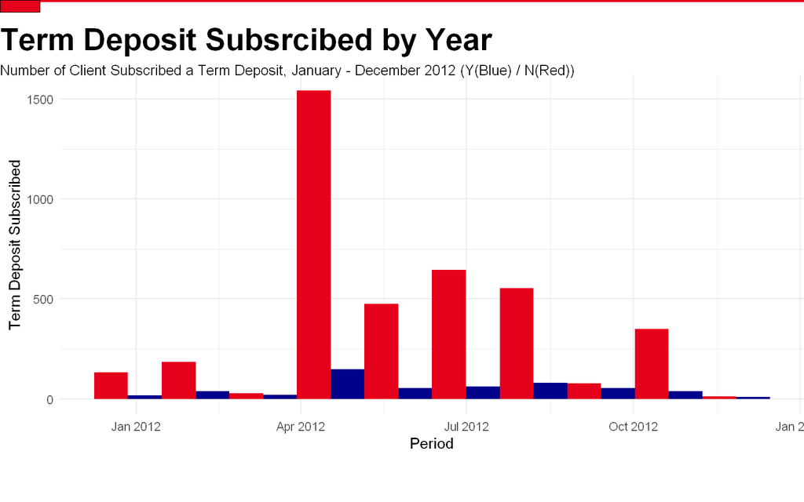

```r
bar_fills <- c("#e5001c", "darkblue")
    plot2 <- ggplot(bmdat, aes(x=year_month, fill= y))+
      geom_histogram(stat = 'bin',
                     bins = 10,
                     position = "dodge") +
      scale_fill_manual(values = bar_fills,
                        guide = "none") +
      xlab('Period') +
      ylab('Term Deposit Subscribed') +
      theme_minimal()

plot2 <- plot2 +  labs(title = NULL, subtitle = NULL) + theme(
  plot.margin = margin(0.15, 0, 0.1, 0.01, "npc"))

plot2

grid.text(
  "Term Deposit Subsrcibed by Year",
  0,
  0.900,
  just = c("left", "bottom"),
  gp = gpar(
    fontsize = 22,
    fontface = "bold",
    fontfamily = "Econ Sans Cnd"
  )
)

grid.text(
  "Number of Client Subscribed a Term Deposit, January - December 2012 (Y(Blue) / N(Red))",
  0,
  0.850,
  just = c("left", "bottom"),
  gp = gpar(
    fontsize = 10,
    fontfamily = "Econ Sans Cnd"
  )
)

grid.lines(
  x = c(0, 1),
  y = 1,
  gp = gpar(col = "#e5001c", lwd = 4)
)

grid.rect(
  x = 0,
  y = 1,
  width = 0.05,
  height = 0.025,
  just = c("left", "top"),
  gp = gpar(fill = "#e5001c", lwd = 0)
)
```

### 5 Demographic Statistics

Visualisasi ke lima ini adalah visualisasi yang digunakan untuk melihat proporsi kepemilikan deposito berjangka terhadap demografi pelanggan.

```r
# Demographic Statistics
bar_fills <- c("#e5001c", "darkblue")
    plot3 <- ggplot(bmdat, aes(y=job, fill= y))+
      geom_histogram(stat = 'count',
                     bins = 20,
                     position = "dodge") +
      scale_fill_manual(values = bar_fills,
                        guide = "none") +
      theme_minimal() + labs(title = "Job") +
      ylab(" ") + xlab(" ")
      theme(axis.text = element_text(size=4))
```

[output not shown]

```r
    plot4 <- ggplot(bmdat, aes(y=marital, fill= y))+
      geom_histogram(stat = 'count',
                     bins = 20,
                     position = "dodge") +
      scale_fill_manual(values = bar_fills,
                        guide = "none") +
      theme_minimal() + labs(title = "Marital Status") +
      ylab(" ") + xlab(" ")
      theme(axis.text = element_text(size=6))
```

[output not shown]

```r
    plot5 <- ggplot(bmdat, aes(y=education, fill= y))+
      geom_histogram(stat = 'count',
                     bins = 20,
                     position = "dodge") +
      scale_fill_manual(values = bar_fills,
                        guide = "none") +
      theme_minimal() + labs(title = "Education") +
      ylab(" ") + xlab(" ")
      theme(axis.text = element_text(size=6))
```

[output not shown]

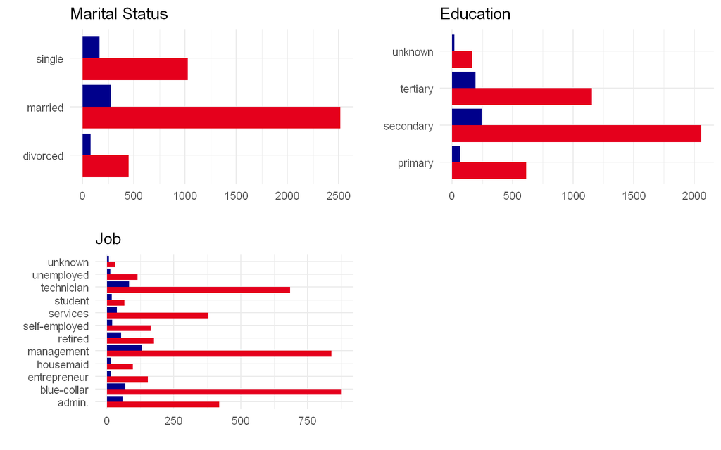

```r
plot345 <- grid.arrange(plot4, plot5, plot3, nrow = 2, ncol = 2)
```

### 6 Housing and Loan Proportion

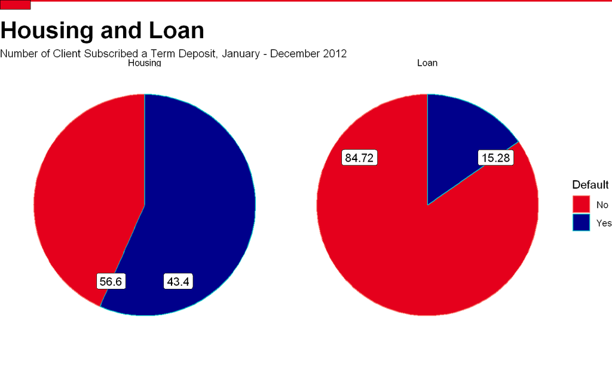

```r
#Create Freq Table and Percent
labels <- c("No","Yes")

default_dat = as.data.frame(table(bmdat$default))
default_dat['Percent'] = round(100*(default_dat$Freq/sum(default_dat$Freq)),2)
housing_dat = as.data.frame(table(bmdat$housing))
housing_dat['Percent'] = round(100*(housing_dat$Freq/sum(housing_dat$Freq)),2)
loan_dat = as.data.frame(table(bmdat$loan))
loan_dat['Percent'] = round(100*(loan_dat$Freq/sum(loan_dat$Freq)),2)

#Create New Sub Data Frame
all_pie = data.frame(subject <- c('Housing','Housing','Loan','Loan'),
                     Default <- c('No','Yes','No','Yes'),
                     value <- c( housing_dat$Freq, loan_dat$Freq),
                     percent <- c( housing_dat$Percent, loan_dat$Percent))

all_pie$subject <- factor(all_pie$subject)
all_pie$Default <- factor(all_pie$Default)

#Plot The Chart
pie_chart <- ggplot(data=all_pie, aes(x=" ", y=value, group=Default, colour=Default, fill=Default, labels=percent)) + geom_bar(width = 1, stat = "identity",) + coord_polar("y", start=0) +  facet_grid(.~ subject) +theme_void() + geom_label(label = percent, nudge_x = 0.25, nudge_y = 0.25, check_overlap = T, color = "black", fill = "white") + scale_fill_manual(values=c("#e5001c", "darkblue"))

pie_chart <- pie_chart +  labs(title = NULL, subtitle = NULL) + theme(
  plot.margin = margin(0.15, 0, 0.1, 0.01, "npc"))

pie_chart

grid.text(
  "Housing and Loan",
  0,
  0.900,
  just = c("left", "bottom"),
  gp = gpar(
    fontsize = 22,
    fontface = "bold",
    fontfamily = "Econ Sans Cnd"
  )
)

grid.text(
  "Number of Client Subscribed a Term Deposit, January - December 2012",
  0,
  0.850,
  just = c("left", "bottom"),
  gp = gpar(
    fontsize = 10,
    fontfamily = "Econ Sans Cnd"
  )
)

grid.lines(
  x = c(0, 1),
  y = 1,
  gp = gpar(col = "#e5001c", lwd = 4)
)

grid.rect(
  x = 0,
  y = 1,
  width = 0.05,
  height = 0.025,
  just = c("left", "top"),
  gp = gpar(fill = "#e5001c", lwd = 0)
)
```

### 7 Correlation

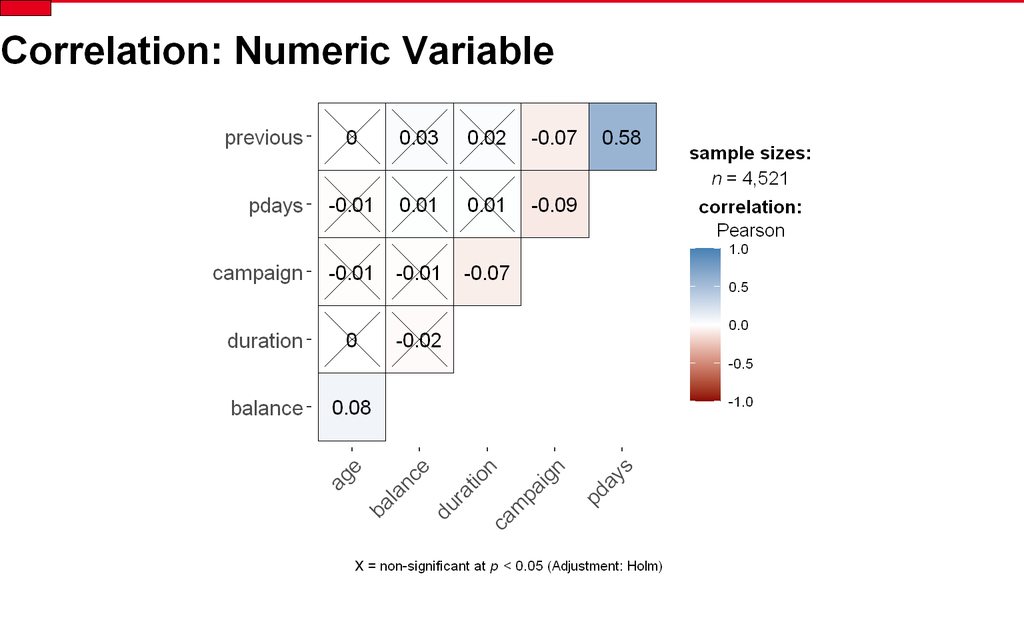

```r
#Correlation between Numeric Variables
corr_numvar <- ggcorrmat(
  data = boxdat,
  type = "parametric", # Person Correlation
  colors = c("darkred", "white", "steelblue")
)

corr_numvar <- corr_numvar +  labs(title = NULL, subtitle = NULL) + theme(
  plot.margin = margin(0.15, 0, 0.1, 0.01, "npc"))

corr_numvar

grid.text(
  "Correlation: Numeric Variable",
  0,
  0.900,
  just = c("left", "bottom"),
  gp = gpar(
    fontsize = 22,
    fontface = "bold",
    fontfamily = "Econ Sans Cnd"
  )
)

grid.lines(
  x = c(0, 1),
  y = 1,
  gp = gpar(col = "#e5001c", lwd = 4)
)

grid.rect(
  x = 0,
  y = 1,
  width = 0.05,
  height = 0.025,
  just = c("left", "top"),
  gp = gpar(fill = "#e5001c", lwd = 0)
)
```

Hasil korelasi menunjukkan bahwa hanya variabel jumlah hari yang berlalu setelah klien terakhir dihubungi dari kampanye sebelumnya dan jumlah kontak yang dilakukan sebelum kampanye yang memiliki korelasi cukup tinggi. Hal ini perlu dilakukan tindak lanjut sebelum dilakukan prediksi.